# Incarceration Report

## **Variable Comparison Chart**

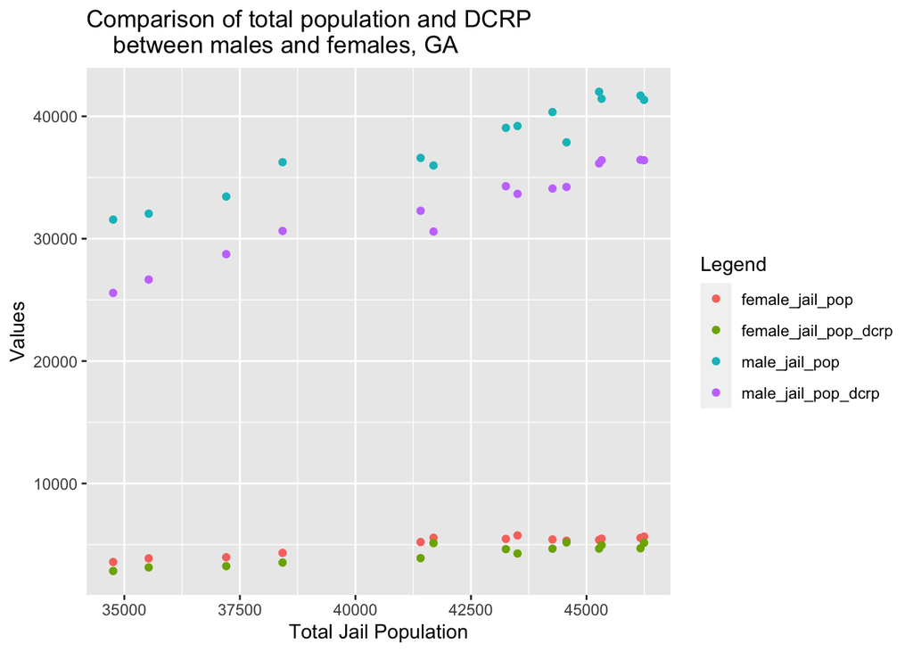

This scatter plot compares the total population and the DCRP which is a voluntary data collection of the persons dying in state prisons, local jails, and in the process of arrest collected by the Bureau of Justice Statistics. This scatter plot shows the relation between continous values. The x axis holds the total jail population and the y axis holds values of female and male jail population and female and male dcrp count. On this graph it can be seen that there are considerbly more males in jail than females. The very last value is from 2013 and it shows that there are 41340 males in jail and 5663 females in jail. The male dcrp is 36409 and the female dcrp is 5155. Proportionally, this shows that more females die in state prisons, local jails or in the process of arrest compared to males.

## **Map**

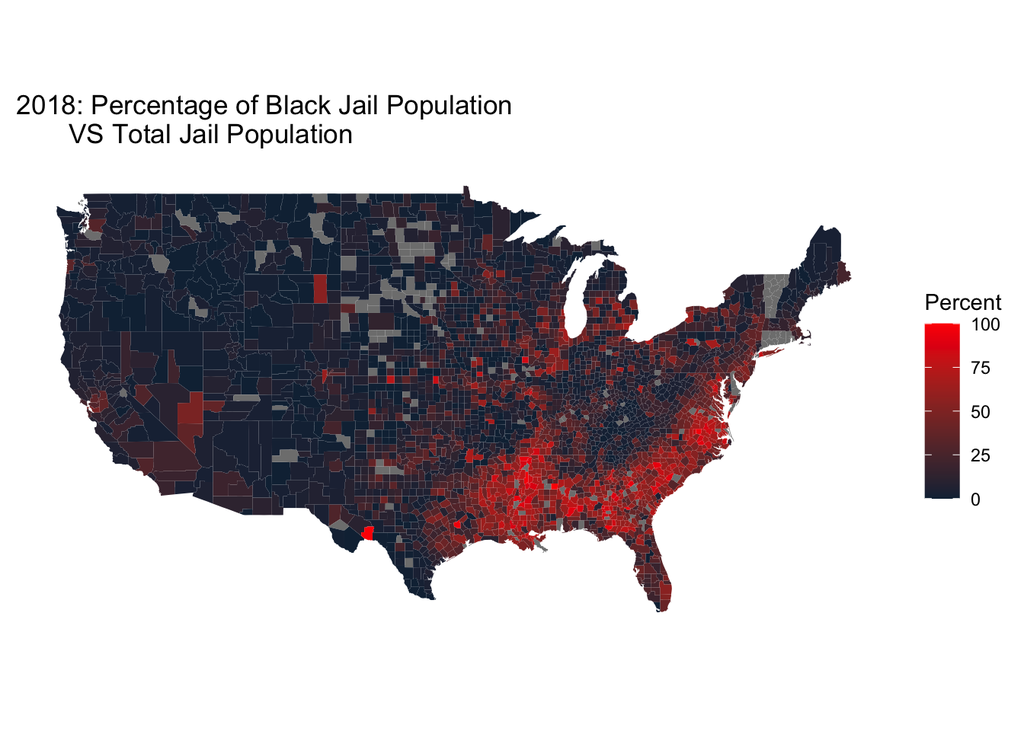